# Analysing spatial patterns of the landscape

Intro2R-spatial workshop

author: [Song, Xiao Ping](https://xp-song.github.io)

updated: 2020-02-11

# 1 Set up

Install necessary packages:

```r
install.packages("tidyverse", dependencies = TRUE)
install.packages("raster", dependencies = TRUE)
install.packages("sf", dependencies = TRUE)
install.packages("landscapetools", dependencies = TRUE)
install.packages("landscapemetrics", dependencies = TRUE)
```

# 2 Prepare data

## 2.1 Quick visualisation

Import only the RGB color bands as individual `RasterLayer` objects:

```r
library(raster)

#blue
b2 <- raster('data/Landsat 8 OLI_TIRS C1 Level-1/LC08_L1TP_125059_20180524_20180605_01_T1/LC08_L1TP_125059_20180524_20180605_01_T1_B2.tif')

#green
b3 <- raster('data/Landsat 8 OLI_TIRS C1 Level-1/LC08_L1TP_125059_20180524_20180605_01_T1/LC08_L1TP_125059_20180524_20180605_01_T1_B3.tif')

#red
b4 <- raster('data/Landsat 8 OLI_TIRS C1 Level-1/LC08_L1TP_125059_20180524_20180605_01_T1/LC08_L1TP_125059_20180524_20180605_01_T1_B4.tif')
```

Combine the `RasterLayer` objects and visualise the satellite image:

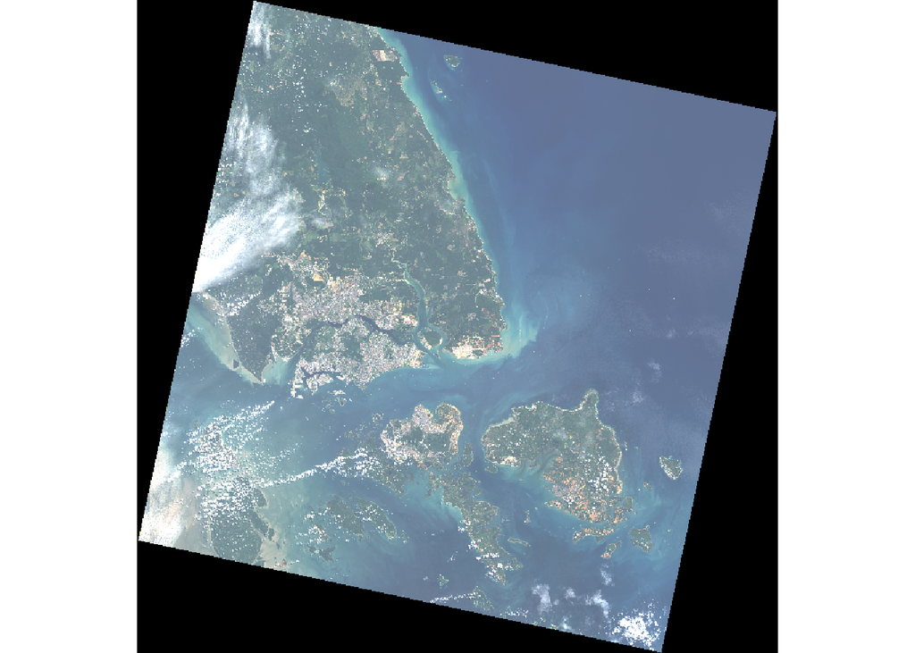

```r
landsatRGB <- stack(b4, b3, b2) #order is impt

plotRGB(landsatRGB,
        stretch = "lin") #scale the values (try using "hist" also)
```

Landsat-8 true color composite (RGB). Source: U.S. Geological Survey.

## 2.2 Import data

Import all 5 bands from the satellite data as a `RasterStack` object named `landsat`:

```r
filenames <- paste0('data/Landsat 8 OLI_TIRS C1 Level-1/LC08_L1TP_125059_20180524_20180605_01_T1/LC08_L1TP_125059_20180524_20180605_01_T1_B', 1:5, ".tif")

landsat <- stack(filenames)

#rename bands
names(landsat) <- c('ultra-blue', 'blue', 'green', 'red', 'NIR')
```

Check coordinate reference system of `landsat`:

```r
crs(landsat)
```

```
## CRS arguments:
##  +proj=utm +zone=48 +datum=WGS84 +units=m +no_defs +ellps=WGS84
## +towgs84=0,0,0
```

## 2.3 Crop data

Import polygon of city boundaries as `sgshp` and check if their coordinate reference systems match:

```r
library(sf)

sgshp <- st_read("data/master-plan-2014-region-boundary-web-shp/MP14_REGION_WEB_PL.shp")
```

Check coordinate reference system of `sgshp`:

```r
crs(sgshp)
```

```
## [1] "+proj=tmerc +lat_0=1.366666666666667 +lon_0=103.8333333333333 +k=1 +x_0=28001.642 +y_0=38744.572 +datum=WGS84 +units=m +no_defs"
```

Transform `sgshp` to the match the coordinate reference system of the `landsat`:

```r
sgshp <- st_transform(sgshp, crs = crs(landsat))
```

Crop `landsat` according to city boundaries:

```r
landsat <- crop(landsat, sgshp) #crop to rectangle

landsat <- mask(landsat, sgshp) #mask values according to shape of sgshp
```

Plot the cropped image using only the RGB bands:

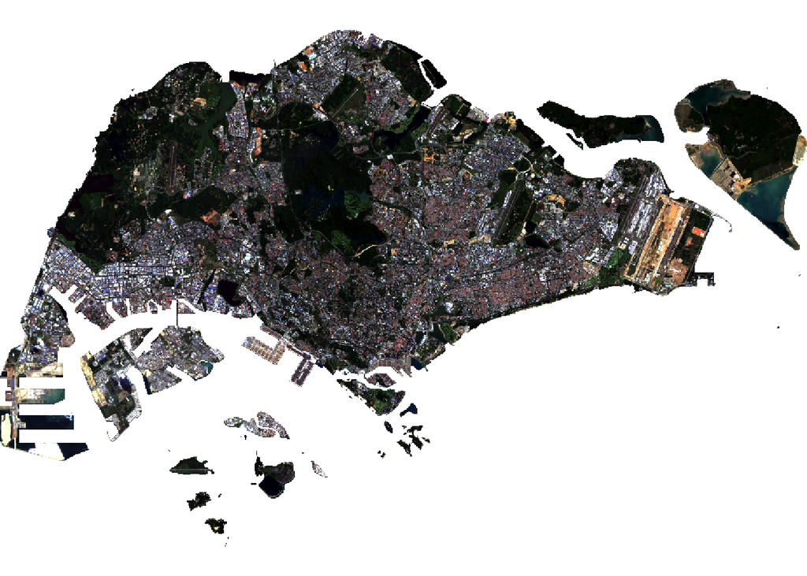

```r
landsatRGB <- subset(landsat, c(4,3,2)) #Red, Green, Blue

plotRGB(landsatRGB,
        stretch = "lin")
```

Landsat-8 true color composite (USGS, 2018) cropped to city boundaries (URA, 2014)

# 3 Classify land cover

## 3.1 Calculate NDVI

Create a function that calcuates the [Normalized Difference Vegetation Index (NDVI)](https://gisgeography.com/ndvi-normalized-difference-vegetation-index/) for each pixel:

```r
ndvi <- function(x, y) {
    (x - y) / (x + y)
  }
```

Apply function to the NIR and Red bands of `landsat`

```r
landsatNDVI <- overlay(landsat[[5]], landsat[[4]],
                       fun = ndvi)
```

Limit the range of values to be from -1 to 1:

```r
landsatNDVI <- reclassify(landsatNDVI, c(-Inf, -1, -1)) # <-1 becomes -1

landsatNDVI <- reclassify(landsatNDVI, c(1, Inf, 1)) # >1 becomes 1
```

## 3.2 Visualise NDVI

Map out the NDVI values:

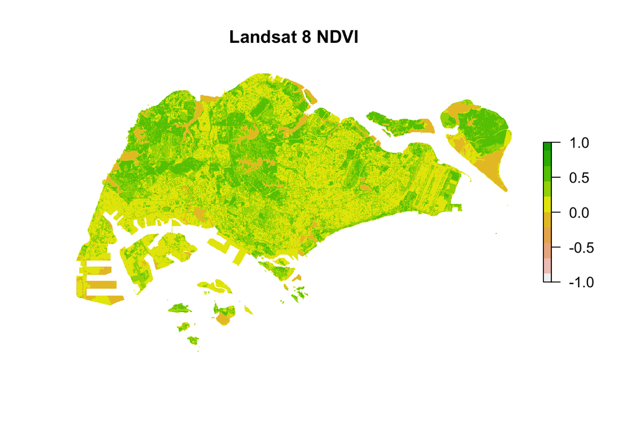

```r
plot(landsatNDVI,
     col = rev(terrain.colors(10)),
     main = "Landsat 8 NDVI",
     axes = FALSE, box = FALSE)
```

Plot histogram of NDVI values:

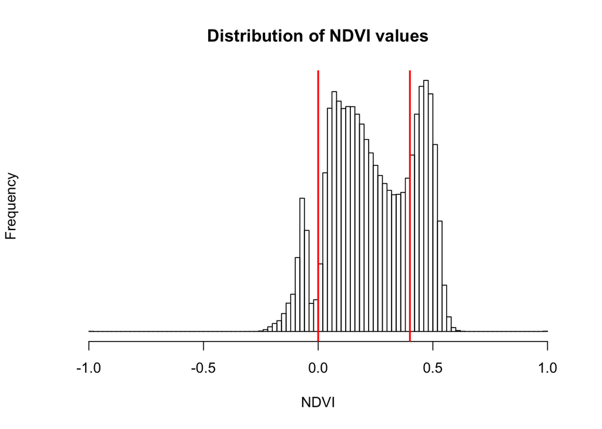

```r
hist(landsatNDVI,
     main = "Distribution of NDVI values", xlab = "NDVI",
     xlim = c(-1, 1), breaks = 100, yaxt = 'n')
abline(v=0.4, col="red", lwd=2)
abline(v=0, col="red", lwd=2)
```

## 3.3 Classify using NDVI

Create a matrix to be used as an argument in the `reclassify()` function:

```r
reclass_m <- matrix(c(-Inf, 0, 1, #water
                      0, 0.4, 2, #urban
                      0.4, Inf, 3), #veg
                    ncol = 3, byrow = TRUE)
reclass_m
```

```
##      [,1] [,2] [,3]
## [1,] -Inf  0.0    1
## [2,]  0.0  0.4    2
## [3,]  0.4  Inf    3
```

Classify land cover using the defined threshold values:

```r
landsatCover <- reclassify(landsatNDVI, reclass_m)
```

Plot the land cover classes:

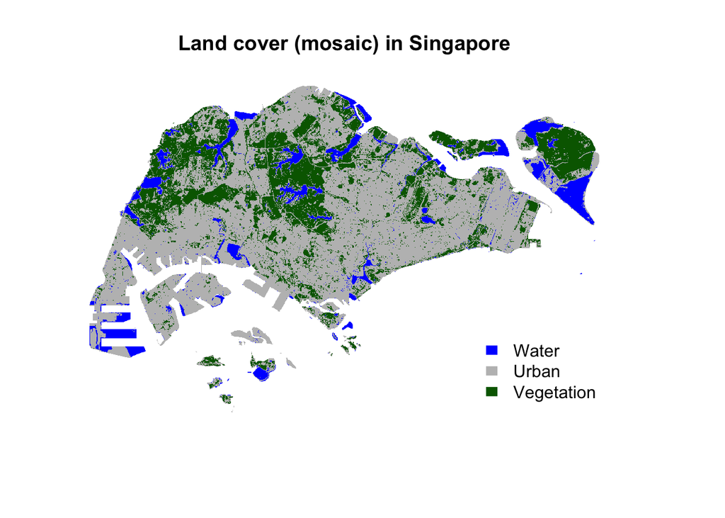

## 3.4 Save raster

Save the reclassified raster `landsatcover` in the GeoTiff format:

```r
writeRaster(landsatCover,
            filename = "clean_data/landsat_landcover.tif",
            overwrite = TRUE)
```

# 4 Landscape metrics

## 4.1 Quick visualisation

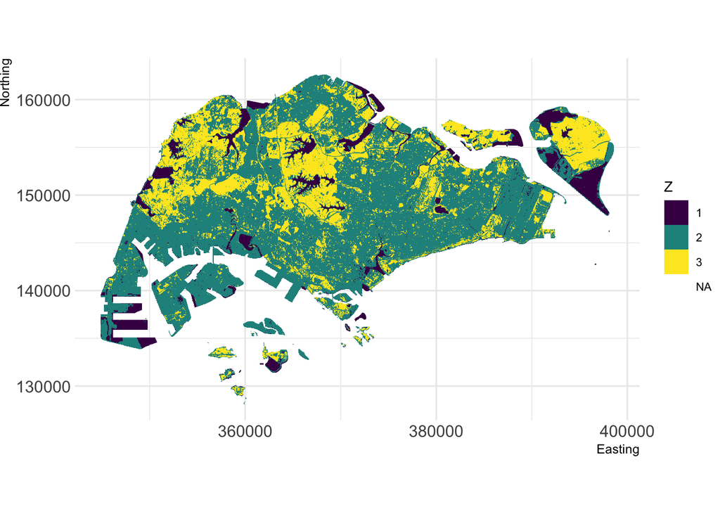

```r
library(landscapemetrics)
library(landscapetools)

#landsatCover <- raster('clean/landsat_landcover.tif') #reload saved raster

show_landscape(landsatCover, discrete = TRUE)
```

Check if the raster data is in the right format:

```r
check_landscape(landsatCover)
```

```
##   layer       crs units   class n_classes OK
## 1     1 projected     m integer         3  ✓
```

## 4.2 Patch-level

E.g. Area of each patch in the landscape:

```r
lsm_p_area(landsatCover)
```

```
## # A tibble: 8,879 x 6
##    layer level class    id metric value
##    <int> <chr> <int> <int> <chr>  <dbl>
##  1     1 patch     1     1 area   14.6
##  2     1 patch     1     2 area    0.09
##  3     1 patch     1     3 area   27.3
##  4     1 patch     1     4 area    0.09
##  5     1 patch     1     5 area    0.18
##  6     1 patch     1     6 area    0.36
##  7     1 patch     1     7 area    0.09
##  8     1 patch     1     8 area    0.09
##  9     1 patch     1     9 area    0.09
## 10     1 patch     1    10 area    0.09
## # … with 8,869 more rows
```

## 4.3 Class-level

E.g. For each class, the total area of all patches:

```r
lsm_c_ca(landsatCover)
```

```
## # A tibble: 3 x 6
##   layer level class    id metric  value
##   <int> <chr> <int> <int> <chr>   <dbl>
## 1     1 class     1    NA ca      6742.
## 2     1 class     2    NA ca     50366.
## 3     1 class     3    NA ca     21063.
```

E.g. For each class, the average area of patches:

```r
lsm_c_area_mn(landsatCover)
```

```
## # A tibble: 3 x 6
##   layer level class    id metric  value
##   <int> <chr> <int> <int> <chr>   <dbl>
## 1     1 class     1    NA area_mn  3.22
## 2     1 class     2    NA area_mn 24.5
## 3     1 class     3    NA area_mn  4.45
```

## 4.4 Landscape-level

E.g. Total area of the landscape (all three land cover classes):

```r
lsm_l_ta(landsatCover)
```

```
## # A tibble: 1 x 6
##   layer level     class    id metric  value
##   <int> <chr>     <int> <int> <chr>   <dbl>
## 1     1 landscape    NA    NA ta     78170.
```

# 5 Credits

Spatial data used in this document:

- Landsat-8 satellite images from the [U.S. Geological Survey](https://earthexplorer.usgs.gov/)
- Singapore [Regional Master Plan 2014](https://data.gov.sg/dataset/master-plan-2014-region-boundary-web) from the Urban Redevelopment Authority

Copyright (c) 2020 Song, Xiao Ping